# Water as a reactant in the differential expression of proteins in cancer (2021)

This vignette runs the code to make the plots from the following paper:

> Dick JM. 2021. Water as a reactant in the differential expression of proteins in cancer. *Computational & Systems Oncology* **1**(1): e1007. doi: 10.1002/cso2.1007

This vignette was compiled on 2025-05-20 with **JMDplots** 1.2.22 and **canprot** 2.0.0.

```r
library(JMDplots)
```

The QEC basis species (glutamine, glutamic acid, cysteine, H<sub>2</sub>O, O<sub>2</sub>) are used for the analysis of stoichiometric hydration state (*n*H<sub>2</sub>O).

## Study overview (Figure 1)

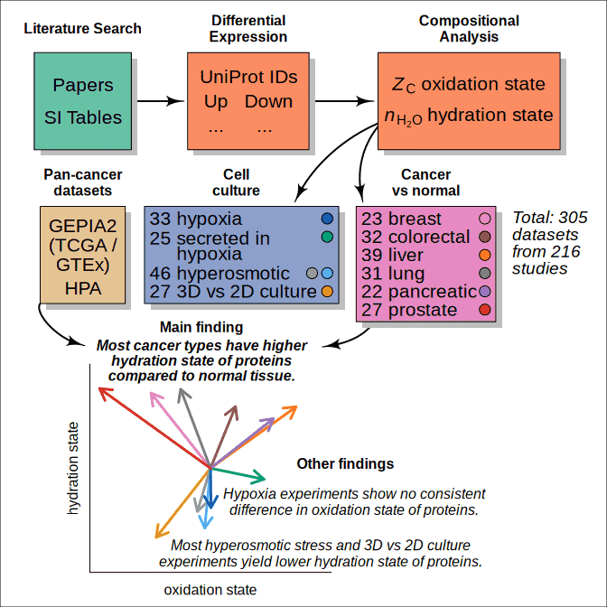

```r
canH2O1()
```

## Median differences of *n*H<sub>2</sub>O and *Z*<sub>C</sub> for cell culture and cancer tissue (Figure 2)

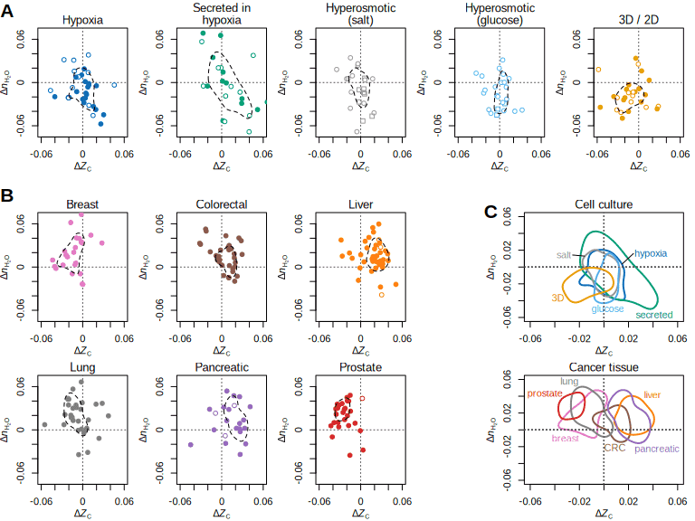

```r
canH2O2()
```

## *n*H<sub>2</sub>O-*Z*<sub>C</sub> plots for TCGA and HPA datasets (Figure 3)

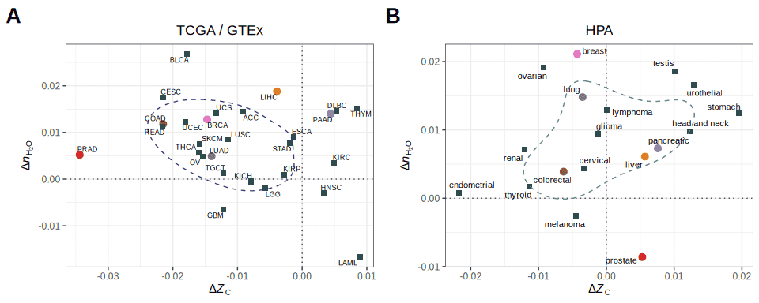

```r
canH2O3()
```

## Differentially expressed genes in aneuploid and osmotically shocked yeast cells (Figure 4)

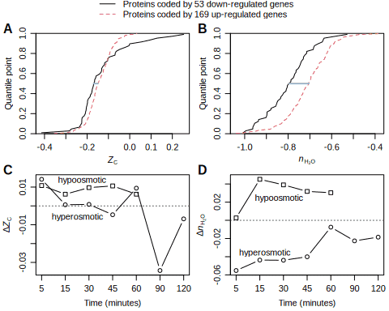

```r
canH2O4()
```

## Mean differences and *p*-values for all datasets in each condition (Table 2)

Mean differences are followed by log<sub>10</sub> of *p*-value in parentheses. Mean differences are computed as (mean of median values for up-regulated proteins in each dataset) - (mean of median values for down-regulated proteins in each dataset). The rows labelled “up” and “down” refer to (mean of median values for [up- or down-]regulated proteins in secreted proteins in hypoxia) - (mean of median values for [up-or down-]regulated proteins in whole-cell extracts in hypoxia).

```r
kable(canH2OT2(), align = "r")
```

|  | Δ*Z*<sub>C</sub> | Δ*n*<sub>H2O</sub> |
| --- | --- | --- |
| hypoxia | 0.000 (-0.0) | -0.009 (**-1.6**) |
| secreted | 0.011 (**-1.4**) | -0.003 (-0.1) |
| salt | -0.003 (-0.5) | -0.010 (-1.0) |
| glucose | -0.001 (-0.1) | -0.014 (**-2.4**) |
| 3D | -0.011 (**-2.0**) | -0.017 (**-3.4**) |
| breast | -0.012 (**-2.7**) | 0.018 (**-2.6**) |
| colorectal | 0.005 (-1.1) | 0.015 (**-3.8**) |
| liver | 0.018 (**-6.7**) | 0.015 (**-4.0**) |
| lung | -0.006 (-1.2) | 0.019 (**-4.1**) |
| pancreatic | 0.013 (**-2.2**) | 0.012 (**-1.5**) |
| prostate | -0.023 (**-9.2**) | 0.019 (**-4.1**) |
| TCGA | -0.009 (**-4.0**) | 0.008 (**-4.0**) |
| HPA | -0.000 (-0.0) | 0.009 (**-3.6**) |
| up | 0.014 (**-2.8**) | -0.008 (-0.7) |
| down | 0.003 (-0.3) | -0.015 (**-1.9**) |

# Supplementary Tables and Figures

## Stoichiometric matrix for amino acids with QEC basis species (Table S1)

```r
kable(canH2OT1())
```

|  | C<sub>5</sub>H<sub>10</sub>N<sub>2</sub>O<sub>3</sub> | C<sub>5</sub>H<sub>9</sub>NO<sub>4</sub> | C<sub>3</sub>H<sub>7</sub>NO<sub>2</sub>S | H<sub>2</sub>O | O<sub>2</sub> |
| --- | --- | --- | --- | --- | --- |
| alanine | 0.4 | 0.2 | 0 | 0.6 | -0.3 |
| cysteine | 0.0 | 0.0 | 1 | 0.0 | 0.0 |
| aspartic acid | 0.2 | 0.6 | 0 | -0.2 | 0.6 |
| glutamic acid | 0.0 | 1.0 | 0 | 0.0 | 0.0 |
| phenylalanine | -0.8 | 2.6 | 0 | -2.2 | -1.9 |
| glycine | 0.6 | -0.2 | 0 | 0.4 | 0.3 |
| histidine | 1.8 | -0.6 | 0 | -1.8 | 0.4 |
| isoleucine | -0.2 | 1.4 | 0 | 1.2 | -2.1 |
| lysine | 0.8 | 0.4 | 0 | 1.2 | -1.6 |
| leucine | -0.2 | 1.4 | 0 | 1.2 | -2.1 |
| methionine | -0.4 | 0.8 | 1 | 0.4 | -1.2 |
| asparagine | 1.2 | -0.4 | 0 | -0.2 | 0.6 |
| proline | 0.0 | 1.0 | 0 | 0.0 | -1.0 |
| glutamine | 1.0 | 0.0 | 0 | 0.0 | 0.0 |
| arginine | 2.8 | -1.6 | 0 | 0.2 | -0.1 |
| serine | 0.4 | 0.2 | 0 | 0.6 | 0.2 |
| threonine | 0.2 | 0.6 | 0 | 0.8 | -0.4 |
| valine | 0.0 | 1.0 | 0 | 1.0 | -1.5 |
| tryptophan | -0.2 | 2.4 | 0 | -3.8 | -1.6 |
| tyrosine | -0.8 | 2.6 | 0 | -2.2 | -1.4 |

## *n*O<sub>2</sub>-*Z*<sub>C</sub> and *n*H<sub>2</sub>O-*Z*<sub>C</sub> correlations using QEC basis species (Figure S1)

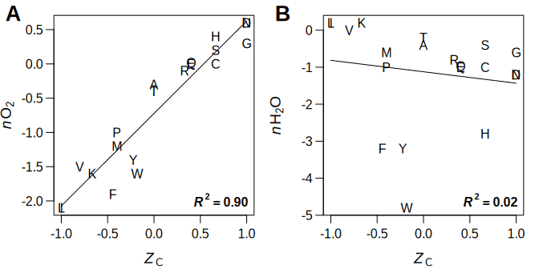

```r
canH2OS1()
```

## HPA-TCGA scatterplots for *Z*<sub>C</sub> and *n*H<sub>2</sub>O (Figure S2)

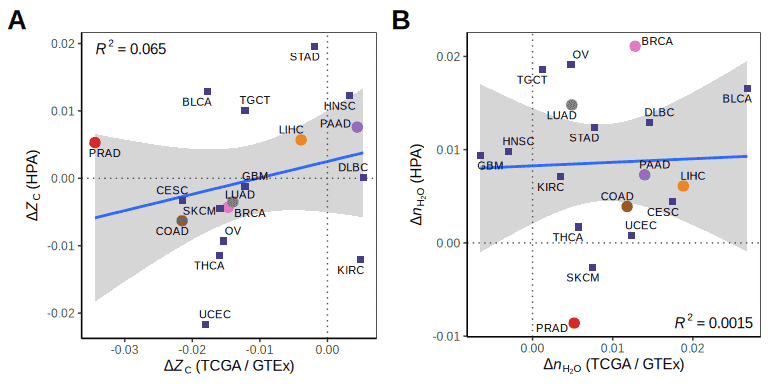

```r
canH2OS2()
```